# Numerical Data: Boxplot and Outliers

Wednesday, February 11, 2026 @ 05:41 PM

## Before We Begin…

These slides are not meant to be standalone information. You should take notes to flesh out the contents. I recommend that you create an R Markdown document where you can combine information and code from the slides and your own additional notes and explorations to make connections.

**Related Materials**

- Ch05 of [*Introduction to Modern Statistics, 2nd Edition*](https://openintro-ims.netlify.app/explore-numerical)
- Ch02 of [*Modern Dive, 2nd Edition*](https://moderndive.com/v2/viz.html)
- Ch03 of [*Modern Dive, 2nd Edition*](https://moderndive.com/v2/wrangling.html)
- DataCamp [*Introduction to the Tidyverse*](https://www.datacamp.com/courses/introduction-to-the-tidyverse)
- DataCamp [*Data Manipulation with dplyr*](https://app.datacamp.com/learn/courses/data-manipulation-with-dplyr)
- DataCamp [*Introduction to Data Visualization with ggplot2*](https://app.datacamp.com/learn/courses/introduction-to-data-visualization-with-ggplot2)

## Recall: Five-Number Summary

Recall that the five-number summary is found by counting the ordered data values so that 25% are grouped into each of the four resulting intervals.

- five-number-summary
  - minimum
  - first quartile (Q<sub>1</sub>)
  - median (“center”)
  - third quartile (Q<sub>3</sub>)
  - maximum
- interquartile range (IQR) = Q<sub>3</sub> - Q<sub>1</sub> (range of middle 50%)

## Count-Based Summaries in R

- `fivenum()`
- `min()`
- `median()`
- `max()`
- `IQR()`
- `range()`
- `diff(range())`
- `quantile()`

For finding quartiles, the `fivenum()` and `quantile()` functions use different methods of calculation, and may produce different results. The `fivenum()` quartiles are the medians of each half of the dataset, also known as Tukey’s *hinges*.

## Visualizing with Boxplots

One of the most common rules for determining outliers is based on the five-number summary. We can visualize the five-number summary and outliers in a boxplot.

[figure not shown]

The mean is not a typical part of a boxplot, but some programs provide it for comparison to the median.

## Determining Outliers

The lower and upper fences determine the limits for potential outliers. The fences are based on the IQR, which is the middle 50% of the data enclosed by the box.

lower fence = LF = Q<sub>1</sub> – 1.5 \(\times\) IQR

upper fence = UF = Q<sub>3</sub> + 1.5 \(\times\) IQR

Some people designate any point more than 3 \(\times\) IQR from the edges of the box as an *extreme outlier*.

## Drawing the Whiskers

Boxplots are also known as box-and-whisker plots. The whiskers are the lines that extend from the box.

- Any value less than the lower fence is a low outlier
- Any value greater than the upper fence is a high outlier
- Outliers are individually indicated by asterisks, circles, etc.
- The lower whisker extends to the smallest data point that is not an outlier (*not* the LF)
- The upper whisker extends to the largest data point that is not an outlier (*not* the UF)

Overall, outliers are determined by the variability of the dataset.

## Some Data to Summarize

- [geyser](https://raw.githubusercontent.com/STAT-JET-ASU/Datasets/master/Instructor/oldfaithful.csv): eruption data for Old Faithful geyser in Yellowstone National Park, including duration in minutes and number of minutes until the next eruption.
- [happyf](https://raw.githubusercontent.com/STAT-JET-ASU/Datasets/master/Instructor/happyface.csv): results for an experiment where some servers drew happy faces on the back of customer’s restaurant checks and others did not, with the tip percentage they received
- [mileage](https://raw.githubusercontent.com/STAT-JET-ASU/Datasets/master/Instructor/gasmileage.csv): results of 100 EPA gas mileage tests for a particular model of car, in miles per gallon (mpg)
- [wells](https://raw.githubusercontent.com/STAT-JET-ASU/Datasets/master/Chihara/Bangladesh.csv): concentration of three contaminants for a sample of wells, in ppb or ppm

In `happyf` the sex of the server is recorded as a binary variable `male` or `female`, since it is an older dataset ([published in 1996](https://onlinelibrary.wiley.com/doi/abs/10.1111/j.1559-1816.1996.tb01847.x)).

```r
glimpse(geyser)
```

```
Rows: 272
Columns: 2
$ erupt_time <dbl> 3.600, 1.800, 3.333, 2.283, 4.533, 2.883, 4.700, 3.600, 1.9…
$ wait_time  <dbl> 79, 54, 74, 62, 85, 55, 88, 85, 51, 85, 54, 84, 78, 47, 83,…
```

```r
glimpse(wells)
```

```
Rows: 271
Columns: 3
$ Arsenic  <dbl> 2400, 6, 904, 321, 1280, 151, 141, 1050, 511, 688, 81, 8, 37,…
$ Chlorine <dbl> 6.2, 116.0, 14.8, 35.9, 18.9, 7.8, 56.3, 16.0, 40.4, 29.3, 31…
$ Cobalt   <dbl> 0.42, 0.45, 0.63, 0.68, 0.58, 0.35, 0.46, 0.59, 0.48, 0.87, 0…
```

You should also `glimpse()` the `happyf` and `mileage` datasets to visualize the structure and variables.

## The Five Number Summary

What is the five-number number summary for the mileage data?

```r
fivenum(mileage$mpg)
```

```
[1] 30.00 35.65 37.00 38.35 44.90
```

Output is a vector of the five values: min, Q<sub>1</sub>, median, Q<sub>3</sub>, max. To get a one of the values, we have to choose it by its location. For example, Q<sub>1</sub> is the second value, or location 2.

```r
fivenum(mileage$mpg)[2]
```

```
[1] 35.65
```

## Calculating the Fences

Lower and upper fences determine the cutoff boundaries for small and large outliers as a function of spread.

```r
(LF_mpg <- fivenum(mileage$mpg)[2] - 1.5 * IQR(mileage$mpg))
```

```
[1] 31.675
```

```r
(UF_mpg <- fivenum(mileage$mpg)[4] + 1.5 * IQR(mileage$mpg))
```

```
[1] 42.325
```

```r
sort(boxplot.stats(mileage$mpg)$out)   # What does boxplot.stats do?
```

```
[1] 30.0 44.9
```

## `boxplot.stats` Function

The `$stats` are the ends of the whiskers, the quartiles, and the median. You also get sample size `$n` and outlier values `$out`.

```r
boxplot.stats(mileage$mpg)
```

```
$stats
[1] 31.80 35.65 37.00 38.35 42.10

$n
[1] 100

$conf
[1] 36.5734 37.4266

$out
[1] 44.9 30.0
```

## Calculating the Fences in dplyr

```r
mileage %>%
  summarize(LF = fivenum(mpg)[2] - 1.5 * IQR(mpg),
            UF = fivenum(mpg)[4] + 1.5 * IQR(mpg))
```

```
# A tibble: 1 × 2
     LF    UF
  <dbl> <dbl>
1  31.7  42.3
```

Use `group_by()` before `summarize()` if you want the fences for separate subgroups in your dataset, or any grouped summaries.

You can also `filter()` the dataset for cases containing outliers using the fences, rather than simply using `boxplot.stats()` to print outlier values. Why might this be more beneficial?

## Boxplot for One Variable

Boxplots may be drawn vertically or horizontally. How does this plot show symmetry? How many outliers are there?

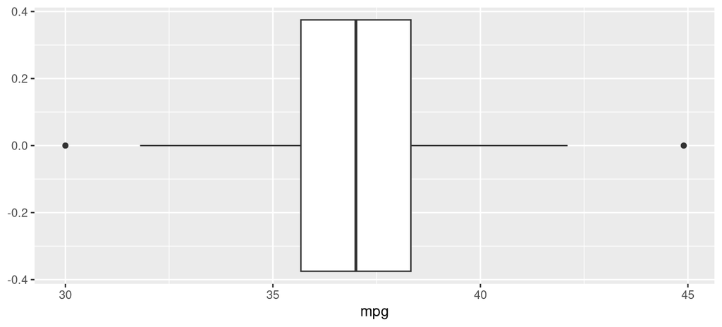

```r
ggplot(mileage, aes(x = mpg)) + geom_boxplot()
```

## Some Simple Formatting

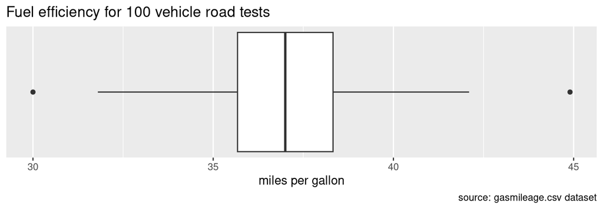

```r
ggplot(mileage, aes(x = mpg)) +
  geom_boxplot() +
  scale_y_continuous(breaks = NULL) +
  labs(title = "Fuel efficiency for 100 vehicle road tests",
       x = "miles per gallon",
       y = NULL,
       caption = "source: gasmileage.csv dataset")
```

## What Shape Are These Data?

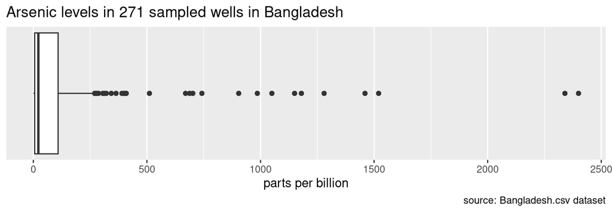

```r
ggplot(wells, aes(x = Arsenic)) +
  geom_boxplot() +
  scale_y_continuous(breaks = NULL) +
  labs(title = "Arsenic levels in 271 sampled wells in Bangladesh",
       x = "parts per billion",
       y = NULL,
       caption = "source: Bangladesh.csv dataset")
```

## Upper and Lower Fences

```r
arsenicfences <- wells %>%
  summarize(LF = fivenum(Arsenic)[2] - 1.5 * IQR(Arsenic),
            UF = fivenum(Arsenic)[4] + 1.5 * IQR(Arsenic))
print.data.frame(arsenicfences)   # provides a neat presentation
```

```
      LF    UF
1 -148.5 263.5
```

Arsenic (measured in parts per billion) cannot be negative, but we can have a negative fence because the mathematics do not take shape or units into account.

- How many outliers are there in the Arsenic variable?
- What are the values of the outliers shown in the boxplot?
- Can you filter the dataset to remove or extract the outliers?

## Extract Outliers for Analysis

```r
LF <- arsenicfences |> pull(LF)   # to get a scalar value
UF <- arsenicfences |> pull(UF)   # to get a scalar value

well_outliers <- wells |>
  filter(Arsenic < LF | Arsenic > UF) |>
  arrange(Arsenic)

glimpse(well_outliers)
```

```
Rows: 28
Columns: 3
$ Arsenic  <dbl> 270, 276, 278, 287, 306, 313, 321, 343, 364, 390, 398, 404, 4…
$ Chlorine <dbl> 390.0, 82.5, 3.6, 140.0, 33.9, 1.7, 35.9, 7.2, 360.0, 67.7, 7…
$ Cobalt   <dbl> 1.28, 1.11, 0.42, 0.58, 0.67, 0.64, 0.68, 0.24, 0.77, 0.80, 0…
```

Does this seem to match up with what you see on the boxplot?

## Remove Outliers from the Data

We found fences for the `mpg` variable earlier, and the boxplot seems to show two outliers.

```r
mileage_out_rem <- mileage |>
  filter(mpg >= LF_mpg, mpg <= UF_mpg)

nrow(mileage_out_rem)
```

```
[1] 98
```

Indeed, two outliers were removed. However, removing outliers could create new ones, since the data summaries might change and outliers are relative to the existing data.

## What Shape Are These Data??

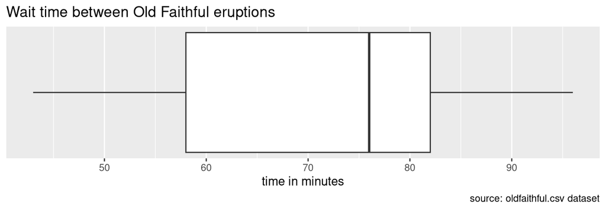

```r
ggplot(geyser, aes(x = wait_time)) +
  geom_boxplot() +
  scale_y_continuous(breaks = NULL) +
  labs(title = "Wait time between Old Faithful eruptions",
       x = "time in minutes",
       y = NULL,
       caption = "source: oldfaithful.csv dataset")
```

## Caution!

We have to be cautious about trying to determine shape with boxplots. They “flatten” the data (there is only one quantitative axis) so we can not see several important features.

Other plots we can use to help determine distribution shape (symmetry versus skew, kurtosis, number of modes) include:

- dotplots
- histograms
- density plots
- ECDF plots

However, none of these plots have a related rule for outliers. This is the strength of boxplots, as well as comparisons.

## Make a Histogram for `erupt_time`

The boxplot obscures that these data are strongly bimodal.

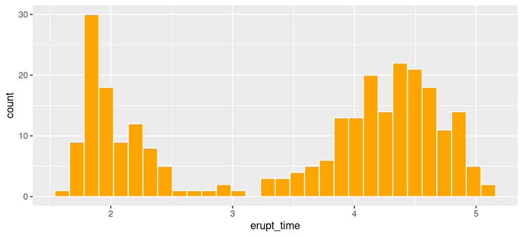

```r
ggplot(geyser, aes(x = erupt_time)) +
  geom_histogram(fill = "orange", color = "white")
```

## Make a Histogram for `mpg`

However, the mileage data seems unimodal and symmetric.

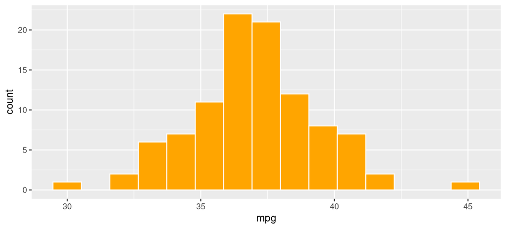

```r
ggplot(mileage, aes(x = mpg)) +
  geom_histogram(bins = 15, fill = "orange", color = "white")
```

## Comparing Groups, Tips by Message

Does drawing a smiley face on a restaurant check increase tips?

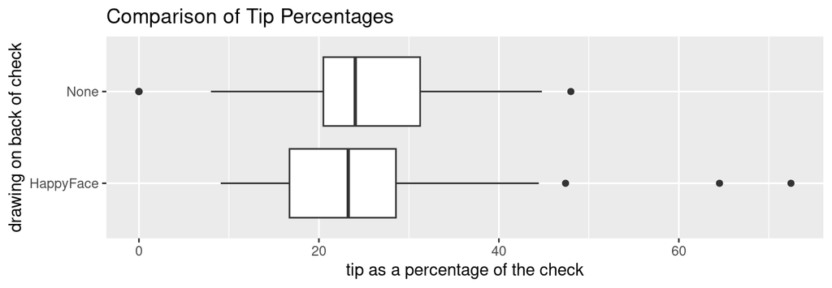

```r
ggplot(happyf, aes(x = TipPct, y = Message)) +
  geom_boxplot() +
  labs(title = "Comparison of Tip Percentages",
       x = "tip as a percentage of the check",
       y = "drawing on back of check")
```

## Adding a Second Variable with Facets

The experiment had two independent variables, sex of server and whether or not they drew happy faces on the backs of the checks. We can add another variable to the plot using facets.

The `facet_grid()` function creates separate plots for a given variable or variables and arranges them in a grid or matrix, as specified by (`rowvariable` ~ `columnvariable`). When you use only one variable, substitute a `.` for the other one.

```r
ggplot(happyf, aes(x = TipPct, y = Message)) +
  geom_boxplot() +
  labs(title = "Comparison of Tip Percentages",
       x = "tip as a percentage of the check",
       y = "drawing on back of check") +
  facet_grid(Sex ~ .)
```

## Faceted Plot with Two Rows

Now we can compare all four of the experimental groups.

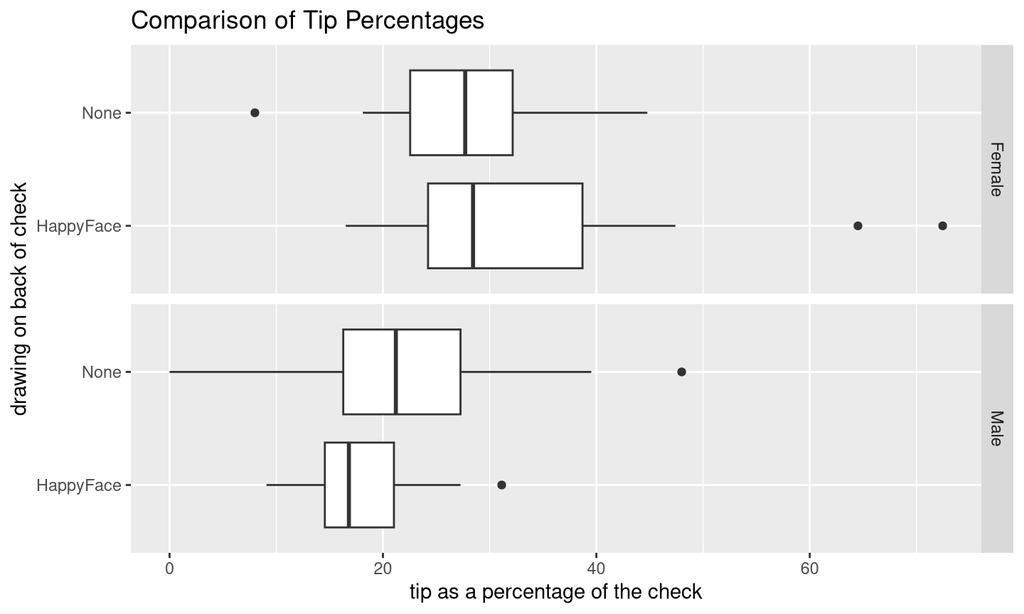

## Fences for Each Group

As mentioned earlier, we use `group_by()` before `summarize()` to calculate fences for each group.

```r
happyf %>%
  group_by(Sex, Message) %>%  # group by Sex and Message
  summarize(LF = fivenum(TipPct)[2] - 1.5 * IQR(TipPct),
            UF = fivenum(TipPct)[4] + 1.5 * IQR(TipPct))
```

```
# A tibble: 4 × 4
# Groups:   Sex [2]
  Sex    Message       LF    UF
  <chr>  <chr>      <dbl> <dbl>
1 Female HappyFace  2.48   62.1
2 Female None       8.14   46.6
3 Male   HappyFace  4.84   30.7
4 Male   None      -0.205  43.8
```

## Vertical vs. Horizontal Boxplots

You can make the plots vertically instead by switching `x` and `y` variables in the aesthetics so that the categorical variable is `x` and the quantitative variable is `y`. Also switch the order of the facet to make columns instead of rows if you are using facets.

```r
ggplot(happyf, aes(x = Message, y = TipPct)) +
  geom_boxplot() +
  labs(title = "Comparison of Tip Percentages",
       y = "tip as a percentage of the check",
       x = "drawing on back of check") +
  facet_grid(. ~ Sex)
```

Choice of vertical or horizontal boxplots is more a matter of personal preference and what helps *you* visualize your data.

## Faceted Plot with Two Columns

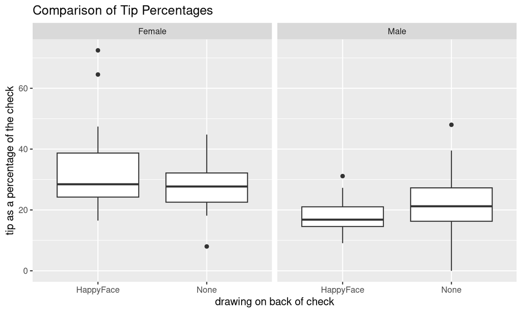